# Final Project Report

Jacob Shoemaker; jshoemaker2249, Qinwen Yang; AngelQinwen, Hongsheng Yin; simonhsy

4/27/2019

Project Coordinator: Jacob Shoemaker, jshoemaker249

Dataset: Olympic History: Athletes and Results

For our DS 202 Final Project, our group chose to analyze data pertaining to olympic athletes and results, accumulated over the past 120 years.

This data was acquired from Kaggle, originally sourced from Olympic enthusiasts. This meant that the data was clean and required very little prep work. With more than 270,000 rows, there was plenty of data to use. Columns included information such as name, year, athlete information (hieght, wieght, sex, age), team, sport, event, and outcome (medal or NA).

From the dataset, we decided to outline the story of our analysis based on the following questions:

## Part 1:

Which particular country produces the most gold medals for any given sport? To begin, this question is vague in the sense that there are many different sports, across both the Summer and Winter games. Therefore, we decided to narrow the scope of this question to the top 5 most popular sports based on the number of tweets in 2012. They are: - Soccer (Football) - Swimming - Track & Field (Athletics) - Gymnastics - Volleyball

Importing the data, changing the Medal column to a factor, and filtering each popular sport into its own dataset:

Then filtering by number of gold medals, picking the top number of teams, and plotting the results:

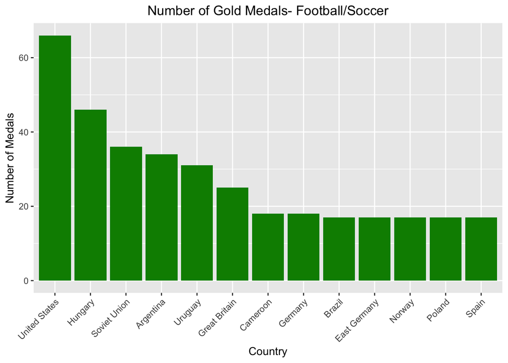

[figure not shown]

[figure not shown]

[figure not shown]

[figure not shown]

```r
df <- football %>% filter(Medal == "Gold") %>% group_by(Team) %>% summarise(numMedals = n())
df <- df[order(-df$numMedals), ] %>% filter(numMedals >= 17)

ggplot(df, aes(x = reorder(Team, -numMedals), y=numMedals)) + geom_col(fill = "green4") + theme(axis.text.x = element_text(angle = 45, hjust = 1)) + ggtitle("Number of Gold Medals- Football/Soccer") + theme(plot.title = element_text(hjust = 0.5))+ xlab("Country") + ylab("Number of Medals")
```

## Part 1, continued:

We also wanted to explore the number of total medals won on an individual country basis. To do this, a choropleth map made the most sense.

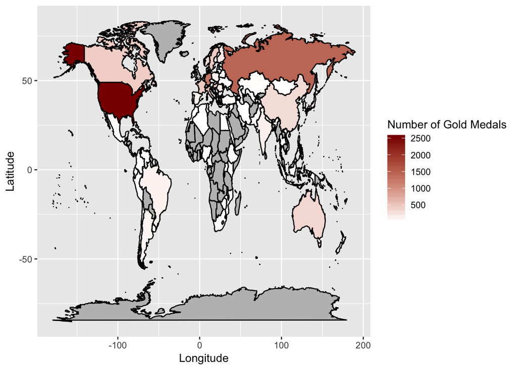

```r
golds <- athlete_events %>% filter(Medal == "Gold")
g <- golds %>% group_by(Team) %>% summarise(numGolds = n())


test <- g
write.csv(test, "goldmedals.csv")

golds_final <- read.csv("goldmedals_final.csv")

countries <- map_data('world')
merged <-  right_join(golds_final, countries, by= c("Team"="region"))
p <- ggplot(merged, aes(x=long, y=lat, fill= numGolds)) + geom_polygon(aes(group=group)) + geom_path(aes(group=group)) + xlab("Longitude") + ylab("Latitude")
p <- p + scale_fill_continuous(low='white', high='darkred', na.value='grey') + labs(fill= "Number of Gold Medals")
p
```

As you can see, the United States, Russia, China, Australia, and a handful of European countries account for most of the medals won in the modern Olympic era. Going forward, it would be interesting to find a map that accounted for changes in country names and borders. In doing so, we would be able to see the success of the Soviet Union.

## Part 2:

Question 1: Number of male and female athletes in 1896?

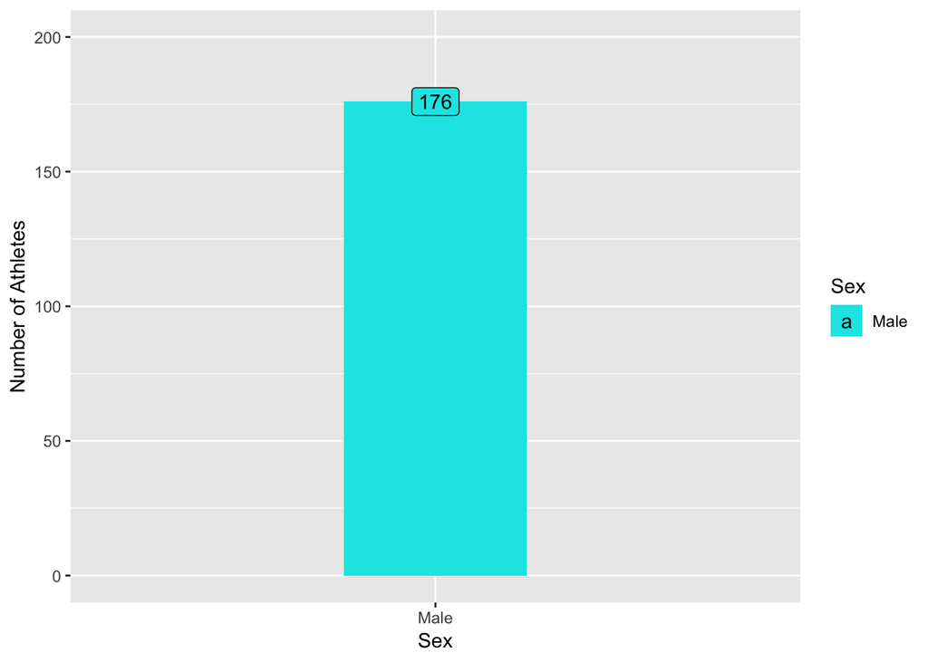

Question 2: Number of male and female athletes in 2016?

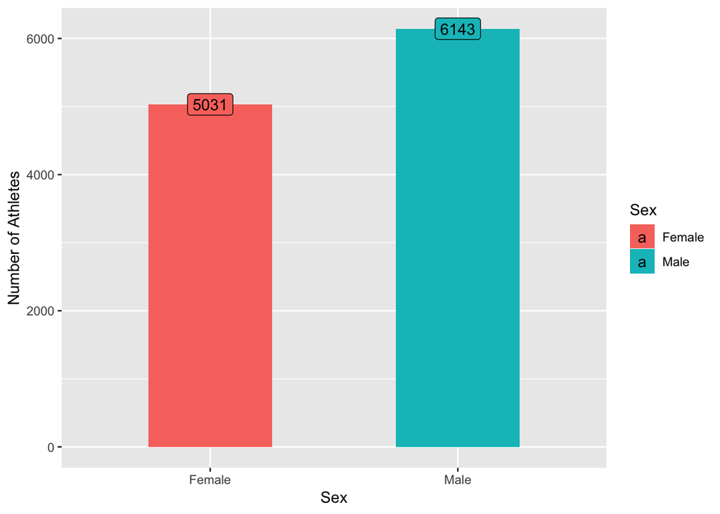

Conclusion: This olympic dataset covers from 1896 to 2016. The first olympic games held in Greek(Athena) in 1896. From the barplot, there’s only 176 athletes total at that time and all of them were male. There’s no women allowed to participate in Olympic games due to the social class and women were considered as a second-class people like slaves and foreigners at that time. For the Olympic games held in Brazil(Rio) in 2016, there’s over eleven thousand athletes, over five thousand were female, over six thousand were male. Although male have the highest number of athletes, there’s not a big difference between number of female and male athletes.

Question 3: Number of male and female athletes each year?

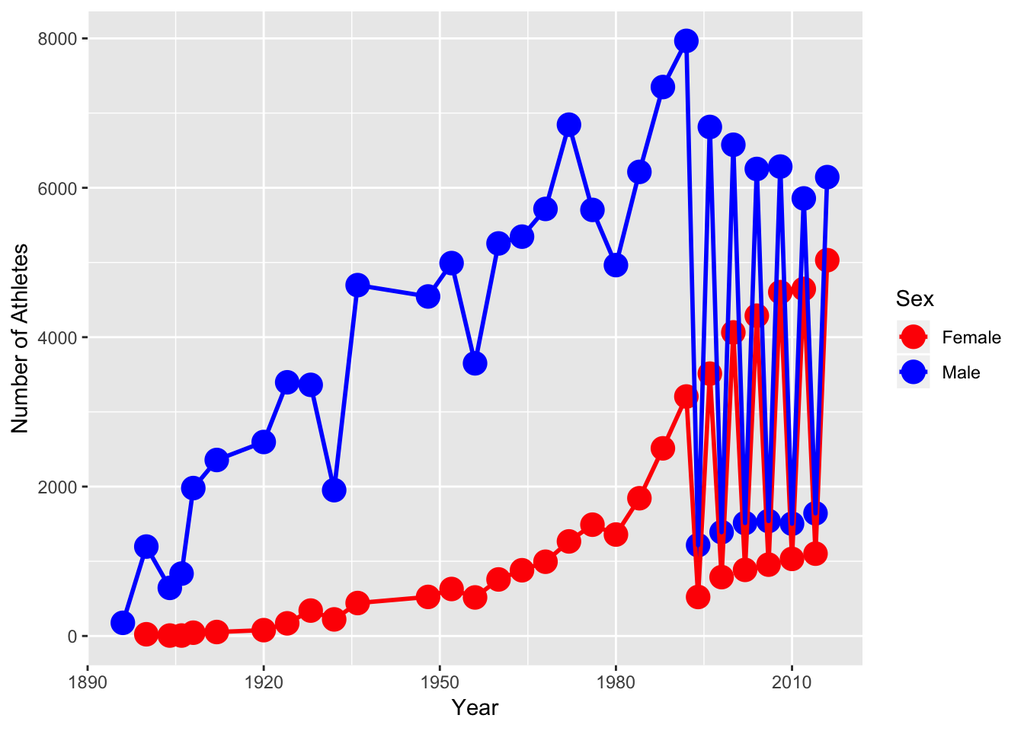

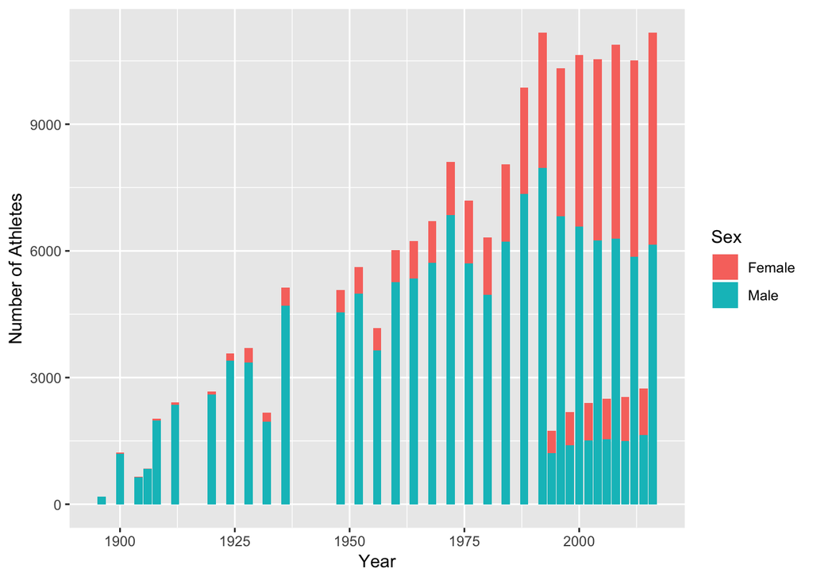

Conclusion: This plot covers the olympic games from 1896 to 2016. From 1896 to 1992, number of athletes in male and female were in a positive relationship which most were in a increase direction. There were few part in decrease direction, and two of them were due to WWI and WWII, olympic games were suspend at that time. After 1992, the plot shows a really strange(huge decrease), it was because winter and summer games were held in same year up to 1992, starting with 1994(winter games), they separate the olympic games into two seasons(summer, winter). Due to separate of winter and summer season, there’s a huge decrease from 1992 to 1994. In addition, since there were more athletes join in summer season than winter season, it contains a continuous wave after 1994. There’s another plot shows the same question but more clear about the change for number of female and male athletes from the years of 1896 to 2016, and the change before and after 1992.

Question 4: Which country first had female athletes? In which year?

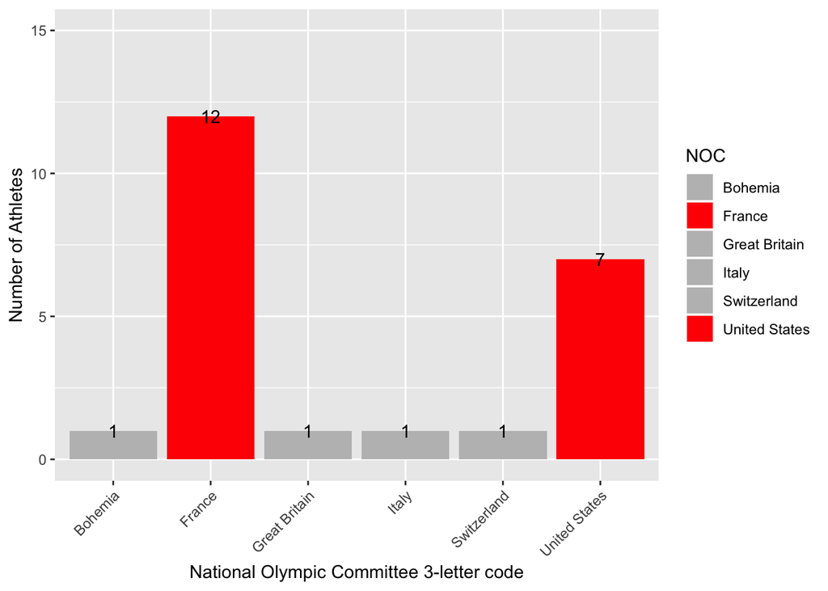

Conclusion: From the data for GroupYearSex in last question, it shows the women were allowed to join olympic games start in 1900. There were six countries started to have female athletes, most female athletes were form France and United States. As total of 23 female athletes at that time, there were 12 from France, 7 from United States.

Question 5: How many sports in 1900? Which sports most female join? Male join?

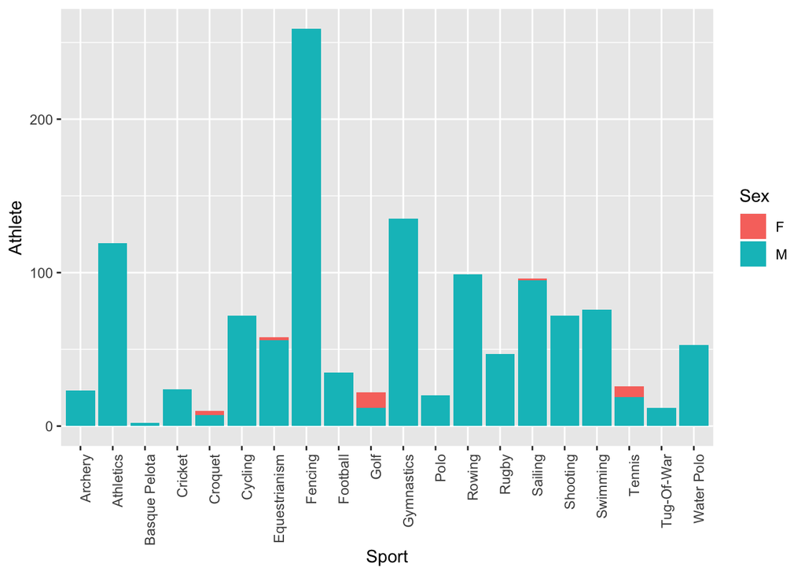

Conclusion: From the plot, it shows there were 20 sports in 1900. Most women join sports in Golf and Tennis. Most men were joining Fencing and Gymnastics.

## Part 3:

- Is there any similar point among the gold medal earners(For example, relationships with cities, height, weight.)?

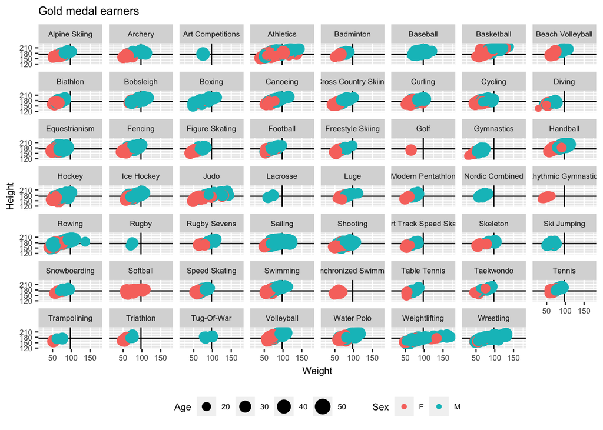

For some sports like gymnastics, it is about the art. They need a good body shape to do some difficult gymnastics poses. But overall, the range of height and weight are pretty normal. Sometimes they just need talents and hardworking but not weight and height.

- Which continent get most gold medals?

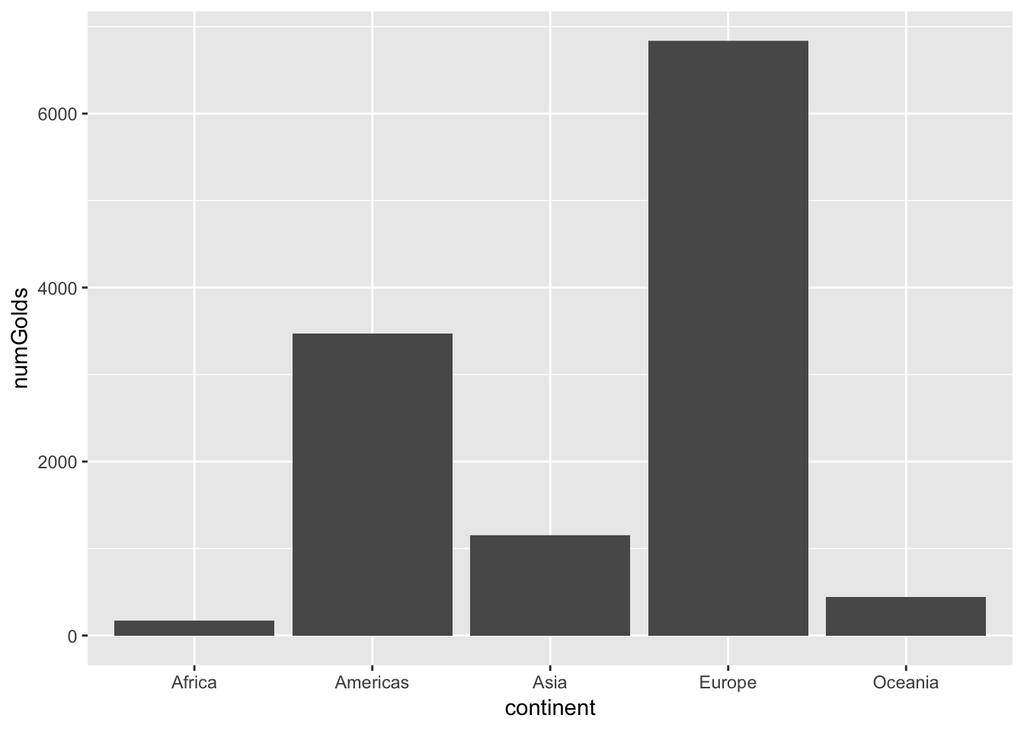

Even the United States got the most gold medals in the world, Europe got the most gold medals compare with other continents because there are more countries in Europe than America.

Sources: [dataset](https://www.kaggle.com/heesoo37/120-years-of-olympic-history-athletes-and-results)

[most popular sports by tweets](https://www.topendsports.com/world/lists/popular-sport/olympics-2012tweets.htm)